# Capstone Project - Syed

Syed Shaheryar Qadir - CIS-627-161

4/21/2020

# “Predicting autism using most impactful gene expressions in the autism spectrum.”

# To read the raw dataset which has been saved in excel format without disturbing the order of the columns.

```r
# X35 refers to the dataset containing gene expressions of patients who underwent neuronal induction at day 35 after exposure.
library(readxl)
require(tidyverse)
require(rvest)
require(data.table)
require(ggthemes)
X35 <-
  read_excel("C:/Users/Junaid/Desktop/Capstone/Genome/dataset/35.xlsx")
head(X35)
```

```
## # A tibble: 6 x 12
##   Symbol `ASD 1` `ASD 2` `ASD 3` `ASD 4` `ASD 5` `ASD 6` `WASD 1` `WASD 2`
##   <chr>    <dbl>   <dbl>   <dbl>   <dbl>   <dbl>   <dbl>    <dbl>    <dbl>
## 1 ENSG0~    7289    7519    4196    2739    1589    3022    16538    11218
## 2 ENSG0~      10      14      19       0       0       1      175      218
## 3 ENSG0~    2891    3485    1637    1673     751    1269     2930     3374
## 4 ENSG0~    1339    1508    1061     466     290     721     1540     1367
## 5 ENSG0~    1220    1283     490     650     329     445     1271     1154
## 6 ENSG0~       1       1       0       1       0       0        0        0
## # ... with 3 more variables: `WASD 3` <dbl>, `WASD 4` <dbl>, `WASD 5` <dbl>
```

```r
# X135 refers to the dataset containing gene expressions of patients who underwent neuronal induction at day 135 after exposure.
library(readxl)
X135 <-
  read_excel("C:/Users/Junaid/Desktop/Capstone/Genome/dataset/135.xlsx")
head(X135)
```

```
## # A tibble: 6 x 12
##   Symbol `ASD 1` `ASD 2` `ASD 3` `ASD 4` `ASD 5` `ASD 6` `WASD 1` `WASD 2`
##   <chr>    <dbl>   <dbl>   <dbl>   <dbl>   <dbl>   <dbl>    <dbl>    <dbl>
## 1 ENSG0~    2023    2687    6580    5558    1450    3236    12473     7163
## 2 ENSG0~       8      12       6     139     100       3       31       12
## 3 ENSG0~     816    1660    2002    2189     932    1073     1371      928
## 4 ENSG0~     372     486    1205    1015     420     577     1022      528
## 5 ENSG0~     301     487     646     709     273     471      456      298
## 6 ENSG0~       2       0       4      14       3       0        0        5
## # ... with 3 more variables: `WASD 3` <dbl>, `WASD 4` <dbl>, `WASD 5` <dbl>
```

# Rename the columns from patient ID to patients with and without ASD

```r
colnames(X35)[2:12] <-
  c(
    "ASD 1",
    "ASD 2",
    "ASD 3",
    "ASD 4",
    "ASD 5",
    "ASD 6",
    "WASD 1",
    "WASD 2",
    "WASD 3",
    "WASD 4",
    "WASD 5"
  )

colnames(X135)[2:12] <-
  c(
    "ASD 1",
    "ASD 2",
    "ASD 3",
    "ASD 4",
    "ASD 5",
    "ASD 6",
    "WASD 1",
    "WASD 2",
    "WASD 3",
    "WASD 4",
    "WASD 5"
  )
```

# Obtain a dataset which subtracts the gene expression of the corresponding patients from both datasets.

```r
# delta refers to the dataset obtained after subtracting both raw datasets to see the difference of growth or reduction in gene expressions

delta <- data.frame(
  Symbol = X35$Symbol,
  ASD1 = X135$`ASD 1` - X35$`ASD 1`,
  ASD2 = X135$`ASD 2` - X35$`ASD 2`,
  ASD3 = X135$`ASD 3` - X35$`ASD 3`,
  ASD4 = X135$`ASD 4` - X35$`ASD 4`,
  ASD5 = X135$`ASD 5` - X35$`ASD 5`,
  ASD6 = X135$`ASD 6` - X35$`ASD 6`,
  WASD1 = X135$`WASD 1` - X35$`WASD 1`,
  WASD2 = X135$`WASD 2` - X35$`WASD 2`,
  WASD3 = X135$`WASD 3` - X35$`WASD 3`,
  WASD4 = X135$`WASD 4` - X35$`WASD 4`,
  WASD5 = X135$`WASD 5` - X35$`WASD 5`
)
```

# The delta dataset looks at the difference of X35 and X135, and then proceeds to add the average column whereas the T20 datasets arrange based on average for ASD and WASD for X35 and X135.

```r
# To find the average of gene expression found in each patient
options(scipen = 999)
delta$avg <- rowMeans(delta[,-1])
delta <- delta %>% arrange(-avg)

# d3 refers to the top 20 rows selected on the base of average
delta20 <- delta[1:20, ]
head(delta20)
```

```
##               Symbol  ASD1   ASD2   ASD3   ASD4  ASD5   ASD6  WASD1   WASD2
## 1  ENSG00000152583.8 26236   5324  94442  62850 32195  16990 173100  102927
## 2 ENSG00000148053.11  -257 -15534 146604  79802 25745 129836  99582   26457
## 3 ENSG00000120885.15 30913   2364 104312  32281  4760  60001 121473  110601
## 4  ENSG00000202198.1   673  86907 428830 170860 49407 231393    685 -888138
## 5  ENSG00000131095.7 30608   2670 184882   9628  6312   7348  79140  133445
## 6 ENSG00000046653.10  4755  -7343  60856  32508  3358  24253  97520   38205
##    WASD3  WASD4  WASD5      avg
## 1  60286  83273  74146 66524.45
## 2  53661  18050  53471 56128.82
## 3  53736  23262  36431 52739.45
## 4 413366 -65767 143285 51954.64
## 5  20722   1140  45409 47391.27
## 6  22176  21264  27957 29591.73
```

# To get average of the gene expressions for day 35

# AVGASD represents the average for the patients with ASD

# WAVGASD represents the average for the patients without ASD

```r
X35$AVGASD <- rowMeans(X35[, 2:7])
X35$AVGWASD <- rowMeans(X35[, 8:12])

T20ASD35 <- head(X35[, c(1:7, 13)] %>% arrange(-AVGASD), 20)
T20ASD35$ASD <- 1

T20WASD35 <- head(X35[, c(1, 8:12, 14)] %>% arrange(-AVGWASD), 20)
T20WASD35$ASD <- 0

#T2035 <- rbind(T20ASD35, T20WASD35)

#ALPHA1 <- unique(T2035)
```

# To get average of the gene expressions for day 135

```r
X135$AVGASD <- rowMeans(X135[, 2:7])
X135$AVGWASD <- rowMeans(X135[, 8:12])

T20ASD135 <- head(X135[, c(1:7, 13)] %>% arrange(-AVGASD), 20)
T20ASD135$ASD <- 1

T20WASD135 <- head(X135[, c(1, 8:12, 14)] %>% arrange(-AVGWASD), 20)
T20WASD135$ASD <- 0

#T20135 <- rbind(T20ASD135, T20WASD135)

#ALPHA2 <- unique(T20135)
```

# Identifying the top 20 impacted genes by comparing just ASD and WASD of 35 against ASD and WASD of 135.

```r
D_AVG_ASD = data.frame(Symbols = T20ASD135$Symbol,
                       `Delta Avg` = T20ASD135$AVGASD - T20ASD35$AVGASD)
D_AVG_ASD <- D_AVG_ASD %>% arrange(-Delta.Avg)


D_AVG_WASD = data.frame(Symbols = T20WASD135$Symbol,
                        `Delta Avg` = T20WASD135$AVGWASD - T20WASD35$AVGWASD)
D_AVG_WASD <- D_AVG_WASD %>% arrange(-Delta.Avg)
```

# Scrapper for labeling genes

```r
delta20$Name <- ""
delta20$Description <- ""
delta20$Synonyms <- ""
delta20$Location <- ""
for (i in 1:nrow(delta20)) {
  url <-
    paste0("https://grch37.ensembl.org/Homo_sapiens/Gene/Summary?g=",
           delta20$Symbol[i])
  name <-
    url %>% read_html() %>%  html_nodes(xpath = '/html/body/div[1]/div/div[2]/div[2]/div[1]/div[1]/h1/text()') %>% html_text() %>% str_replace("Gene: ", "") %>% str_replace(" ", "")
  desc <-
    url %>% read_html() %>%  html_nodes(xpath = '/html/body/div[1]/div/div[2]/div[2]/div[1]/div[2]/div/div[1]/div[1]/div[2]/p/text()[1]') %>% html_text()
  syn <-
    url %>% read_html() %>%  html_nodes(xpath = '/html/body/div[1]/div/div[2]/div[2]/div[1]/div[2]/div/div[1]/div[2]/div[2]/p') %>% html_text()
  loc <-
    url %>% read_html() %>%  html_nodes(xpath = '/html/body/div[1]/div/div[2]/div[2]/div[1]/div[2]/div/div[1]/div[3]/div[2]/p[1]') %>% html_text()
  delta20$Name[i] <- name
  delta20$Description[i] <- desc
  delta20$Synonyms[i] <- syn
  delta20$Location[i] <- loc
}


D_AVG_ASD$Name <- ""
D_AVG_ASD$Description <- ""
D_AVG_ASD$Synonyms <- ""
D_AVG_ASD$Location <- ""
for (i in 1:nrow(D_AVG_ASD)) {
  url <-
    paste0("https://grch37.ensembl.org/Homo_sapiens/Gene/Summary?g=",
           D_AVG_ASD$Symbol[i])
  name <-
    url %>% read_html() %>%  html_nodes(xpath = '/html/body/div[1]/div/div[2]/div[2]/div[1]/div[1]/h1/text()') %>% html_text() %>% str_replace("Gene: ", "") %>% str_replace(" ", "")
  desc <-
    url %>% read_html() %>%  html_nodes(xpath = '/html/body/div[1]/div/div[2]/div[2]/div[1]/div[2]/div/div[1]/div[1]/div[2]/p/text()[1]') %>% html_text()
  syn <-
    url %>% read_html() %>%  html_nodes(xpath = '/html/body/div[1]/div/div[2]/div[2]/div[1]/div[2]/div/div[1]/div[2]/div[2]/p') %>% html_text()
  loc <-
    url %>% read_html() %>%  html_nodes(xpath = '/html/body/div[1]/div/div[2]/div[2]/div[1]/div[2]/div/div[1]/div[3]/div[2]/p[1]') %>% html_text()
  D_AVG_ASD$Name[i] <- name
  D_AVG_ASD$Description[i] <- desc
  D_AVG_ASD$Synonyms[i] <- syn
  D_AVG_ASD$Location[i] <- loc
}


D_AVG_WASD$Name <- ""
D_AVG_WASD$Description <- ""
D_AVG_WASD$Synonyms <- ""
D_AVG_WASD$Location <- ""
for (i in 1:nrow(D_AVG_WASD)) {
  url <-
    paste0("https://grch37.ensembl.org/Homo_sapiens/Gene/Summary?g=",
           D_AVG_WASD$Symbol[i])
  name <-
    url %>% read_html() %>%  html_nodes(xpath = '/html/body/div[1]/div/div[2]/div[2]/div[1]/div[1]/h1/text()') %>% html_text() %>% str_replace("Gene: ", "") %>% str_replace(" ", "")
  desc <-
    url %>% read_html() %>%  html_nodes(xpath = '/html/body/div[1]/div/div[2]/div[2]/div[1]/div[2]/div/div[1]/div[1]/div[2]/p/text()[1]') %>% html_text()
  syn <-
    url %>% read_html() %>%  html_nodes(xpath = '/html/body/div[1]/div/div[2]/div[2]/div[1]/div[2]/div/div[1]/div[2]/div[2]/p') %>% html_text()
  loc <-
    url %>% read_html() %>%  html_nodes(xpath = '/html/body/div[1]/div/div[2]/div[2]/div[1]/div[2]/div/div[1]/div[3]/div[2]/p[1]') %>% html_text()
  D_AVG_WASD$Name[i] <- name
  D_AVG_WASD$Description[i] <- desc
  D_AVG_WASD$Synonyms[i] <- syn
  D_AVG_WASD$Location[i] <- loc
}



# Assigned to be pushed to SQL for later use
top20bi <- delta20
```

# Exploratory Data Analysis

```r
# To create a treemap to display hierarchical  data using nested rectangles.

require(treemap)
treemap(
  delta20,
  index = c("Synonyms"),
  type = "value",
  vSize = "avg",
  vColor = "avg",
  palette = "RdBu",
  title = "Gene Synonyms and Average Gene Expression",
  title.legend = "Average Gene Expression Change"
)
```

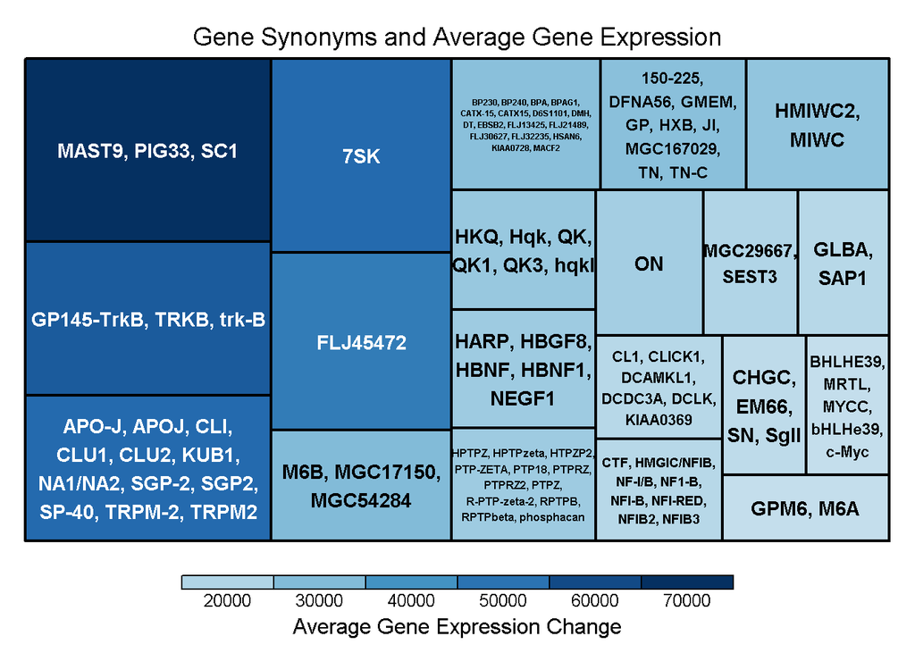

```r
treemap(
  delta20,
  index = c("Name"),
  type = "index",
  vSize = "avg",
  vColor = "avg",
  palette = "RdBu",
  title = "Gene Names and Average Gene Expression"
)
```

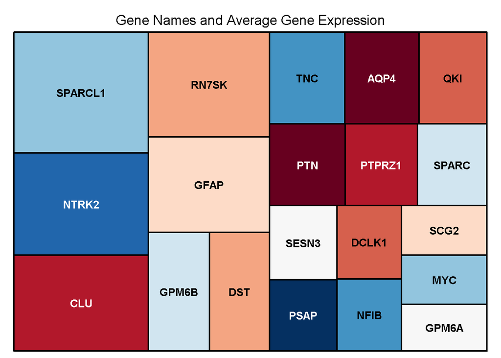

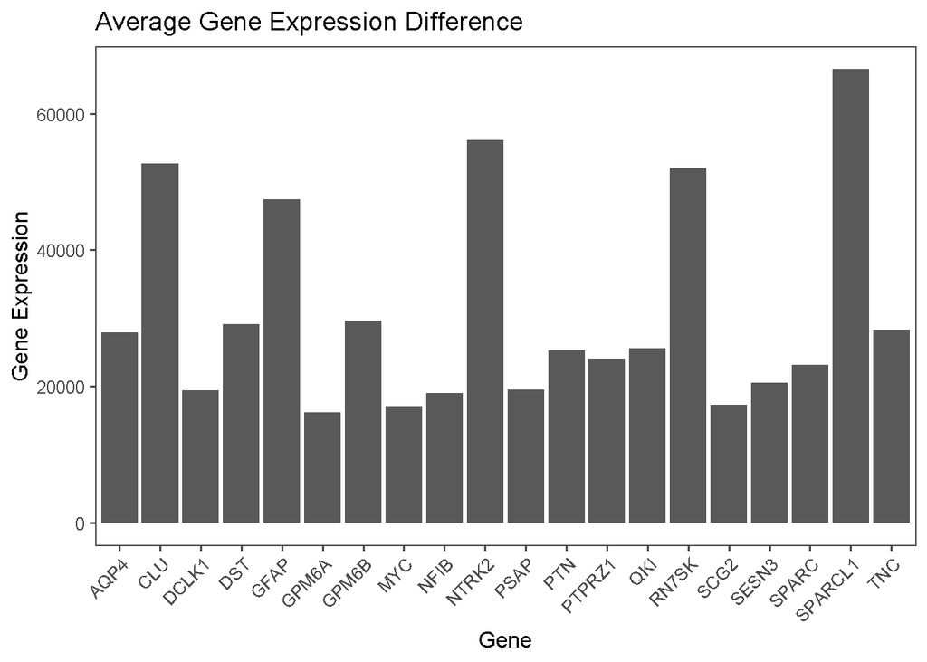

```r
# To look at the dominant genes using a bar plot

ggplot(delta20, aes(x = Name, y = avg)) +
  geom_bar(stat = "identity") +
  labs(title = "Average Gene Expression Difference" ,  x = "Gene",  y = "Gene Expression") +
  theme_few() + scale_fill_gdocs() + theme(axis.text.x = element_text(angle = 45, hjust = 1))
```

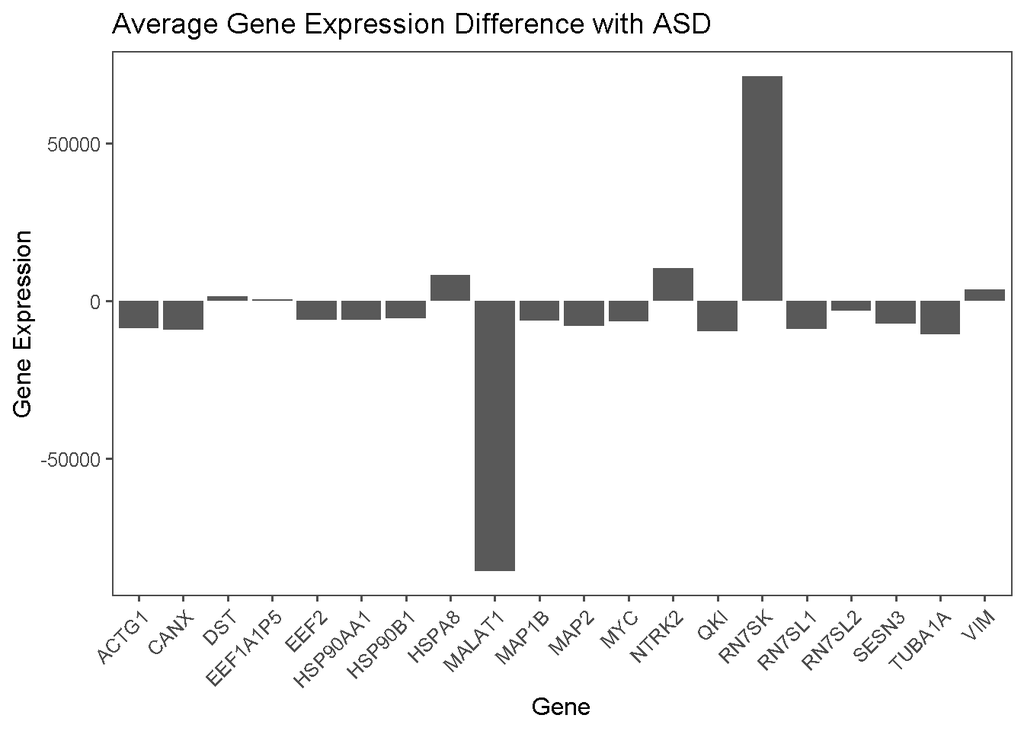

```r
ggplot(D_AVG_ASD, aes(x = Name, y = `Delta.Avg`)) +
  geom_bar(stat = "identity") +
  labs(title = "Average Gene Expression Difference with ASD" ,  x = "Gene",  y = "Gene Expression") +
  theme_few() + scale_fill_gdocs() +theme(axis.text.x = element_text(angle = 45, hjust = 1))
```

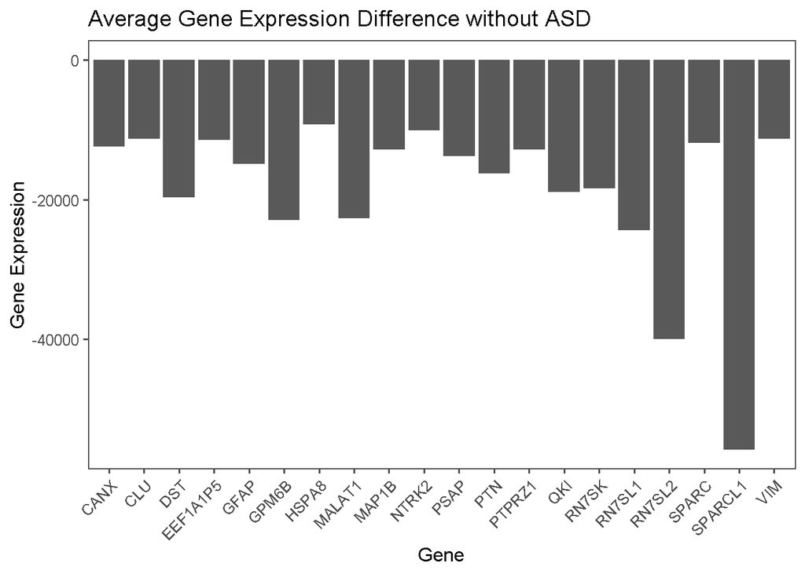

```r
ggplot(D_AVG_WASD, aes(x = Name, y = Delta.Avg)) +
  geom_bar(stat = "identity") +
  labs(title = "Average Gene Expression Difference without ASD" ,  x = "Gene",  y = "Gene Expression") +
  theme_few() + scale_fill_gdocs() +theme(axis.text.x = element_text(angle = 45, hjust = 1))
```

# Tidying the data to transpose it in order to get a visualization with patients on the x axis

```r
t.delta20 <- data.frame(t(delta20[-1]))
colnames(t.delta20) <- delta20[,1]


t.delta20$Patient_ID <- c(1:16)
t.delta20 <- t.delta20[1:11, ]
t.delta20$Patient_ID <- as.factor(t.delta20$Patient_ID)

t.delta20$ASD <- c(1,1,1,1,1,1,0,0,0,0,0)
```

# Visualing the top impacted gene in comparision of ASD vs non ASD patient

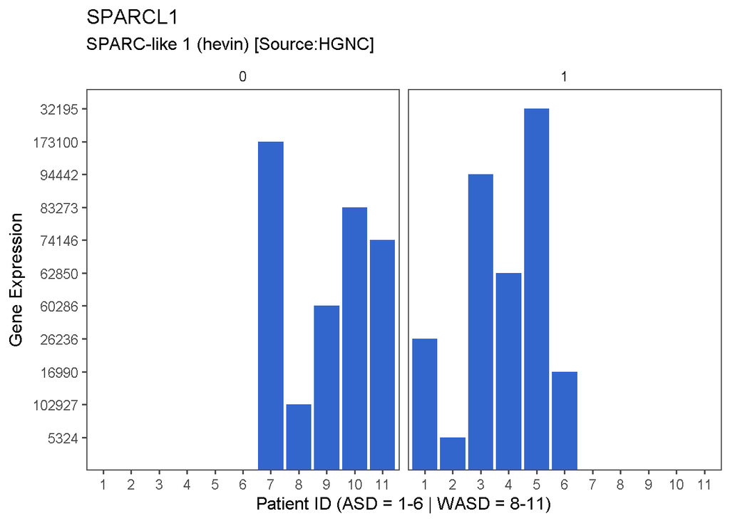

```r
ggplot(
  data = t.delta20,
  mapping = aes(y = ENSG00000152583.8, x = Patient_ID, fill = "red")
) +

  geom_bar(stat = "identity",
           position = "dodge",
           show.legend = F) +
  facet_wrap( ~ ASD) +
  labs(
    title = "SPARCL1" ,
    y = "Gene Expression",
    x = "Patient ID (ASD = 1-6 | WASD = 8-11)",
    subtitle = "SPARC-like 1 (hevin) [Source:HGNC]"
  ) +
  theme(axis.text.x = element_text(angle = 45, hjust = 1))+theme_few() + scale_fill_gdocs()
```

# Taking the top 10 highlighted genes to gain initial overview of the data via SPLOM (scatter plot of matrices)

```r
library(psych)
```

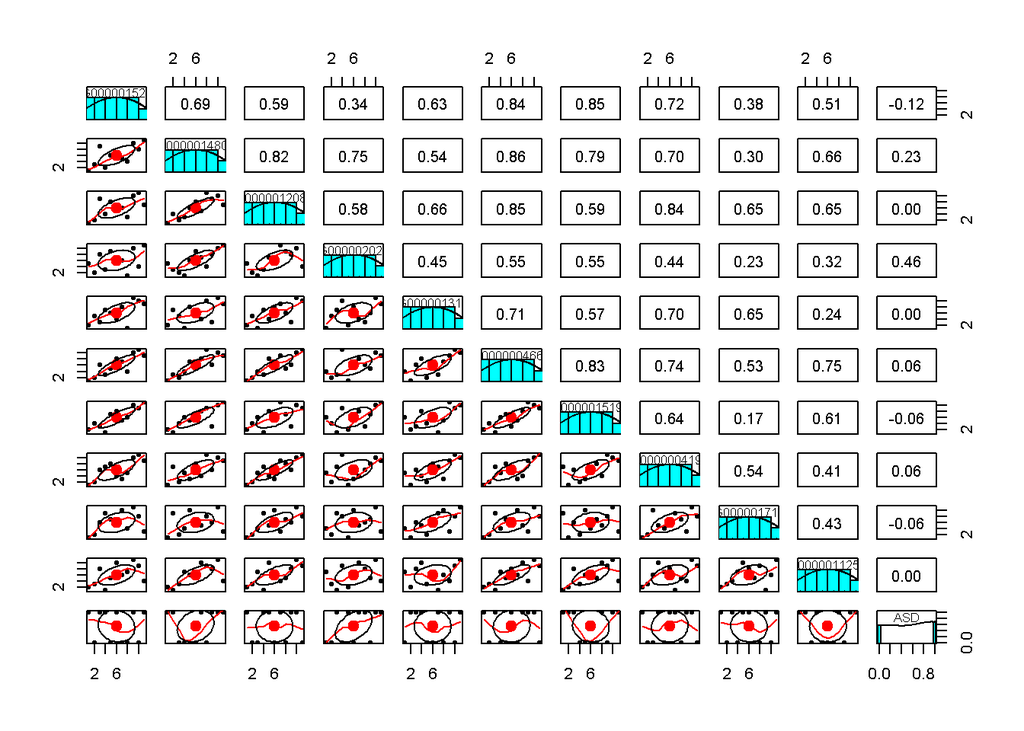

```r
t.delta10.pairs <- subset(t.delta20[, c(1:10, 22)])
pairs.panels(t.delta10.pairs)
```

# Model Building

```r
# To create a dataset which stacks the patients and their corresponding gene expressions for each gene and whether they had ASD or not.
#Patient 1
ASD35P1 <- merge(delta20, X35[, c(1, 2)], by = "Symbol")
ASDP1 <- ASD35P1[, c(1, 14,18)]
ASDP1$Patient <- "ASD1"
ASDP1$Autism <- 1
ASDP1 <- ASDP1 %>% rename (X35 = `ASD 1`)
ASDP1 <- merge(ASDP1, X135[, c(1, 2)], by = "Symbol")
ASDP1 <- ASDP1 %>% rename (X135 = `ASD 1`)

#Patient 2
ASD35P2 <- merge(delta20, X35[, c(1, 3)], by = "Symbol")
ASDP2 <- ASD35P2[, c(1, 14,18)]
ASDP2$Patient <- "ASD2"
ASDP2$Autism <- 1
ASDP2 <- ASDP2 %>% rename (X35 = `ASD 2`)
ASDP2 <- merge(ASDP2, X135[, c(1, 3)], by = "Symbol")
ASDP2 <- ASDP2 %>% rename (X135 = `ASD 2`)

#Patient 3
ASD35P3 <- merge(delta20, X35[, c(1, 4)], by = "Symbol")
ASDP3 <- ASD35P3[, c(1, 14,18)]
ASDP3$Patient <- "ASD3"
ASDP3$Autism <- 1
ASDP3 <- ASDP3 %>% rename (X35 = `ASD 3`)
ASDP3 <- merge(ASDP3, X135[, c(1, 4)], by = "Symbol")
ASDP3 <- ASDP3 %>% rename (X135 = `ASD 3`)


#Patient 4
ASD35P4 <- merge(delta20, X35[, c(1, 5)], by = "Symbol")
ASDP4 <- ASD35P4[, c(1, 14,18)]
ASDP4$Patient <- "ASD4"
ASDP4$Autism <- 1
ASDP4 <- ASDP4 %>% rename (X35 = `ASD 4`)
ASDP4 <- merge(ASDP4, X135[, c(1, 5)], by = "Symbol")
ASDP4 <- ASDP4 %>% rename (X135 = `ASD 4`)

#Patient 5
ASD35P5 <- merge(delta20, X35[, c(1, 6)], by = "Symbol")
ASDP5 <- ASD35P5[, c(1, 14,18)]
ASDP5$Patient <- "ASD5"
ASDP5$Autism <- 1
ASDP5 <- ASDP5 %>% rename (X35 = `ASD 5`)
ASDP5 <- merge(ASDP5, X135[, c(1, 6)], by = "Symbol")
ASDP5 <- ASDP5 %>% rename (X135 = `ASD 5`)

#Patient 6
ASD35P6 <- merge(delta20, X35[, c(1, 7)], by = "Symbol")
ASDP6 <- ASD35P6[, c(1, 14,18)]
ASDP6$Patient <- "ASD6"
ASDP6$Autism <- 1
ASDP6 <- ASDP6 %>% rename (X35 = `ASD 6`)
ASDP6 <- merge(ASDP6, X135[, c(1, 7)], by = "Symbol")
ASDP6 <- ASDP6 %>% rename (X135 = `ASD 6`)


#Patient 7
ASD35P7 <- merge(delta20, X35[, c(1, 8)], by = "Symbol")
ASDP7 <- ASD35P7[, c(1, 14,18)]
ASDP7$Patient <- "WASD1"
ASDP7$Autism <- 0
ASDP7 <- ASDP7 %>% rename (X35 = `WASD 1`)
ASDP7 <- merge(ASDP7, X135[, c(1, 8)], by = "Symbol")
ASDP7 <- ASDP7 %>% rename (X135 = `WASD 1`)


#Patient 8
ASD35P8 <- merge(delta20, X35[, c(1, 9)], by = "Symbol")
ASDP8 <- ASD35P8[, c(1, 14,18)]
ASDP8$Patient <- "WASD2"
ASDP8$Autism <- 0
ASDP8 <- ASDP8 %>% rename (X35 = `WASD 2`)
ASDP8 <- merge(ASDP8, X135[, c(1, 9)], by = "Symbol")
ASDP8 <- ASDP8 %>% rename (X135 = `WASD 2`)


#Patient 9
ASD35P9 <- merge(delta20, X35[, c(1, 10)], by = "Symbol")
ASDP9 <- ASD35P9[, c(1, 14,18)]
ASDP9$Patient <- "WASD3"
ASDP9$Autism <- 0
ASDP9 <- ASDP9 %>% rename (X35 = `WASD 3`)
ASDP9 <- merge(ASDP9, X135[, c(1, 10)], by = "Symbol")
ASDP9 <- ASDP9 %>% rename (X135 = `WASD 3`)



#Patient 10
ASD35P10 <- merge(delta20, X35[, c(1, 11)], by = "Symbol")
ASDP10 <- ASD35P10[, c(1, 14,18)]
ASDP10$Patient <- "WASD4"
ASDP10$Autism <- 0
ASDP10 <- ASDP10 %>% rename (X35 = `WASD 4`)
ASDP10 <- merge(ASDP10, X135[, c(1, 11)], by = "Symbol")
ASDP10 <- ASDP10 %>% rename (X135 = `WASD 4`)



#Patient 11
ASD35P11 <- merge(delta20, X35[, c(1, 12)], by = "Symbol")
ASDP11 <- ASD35P11[, c(1, 14,18)]
ASDP11$Patient <- "WASD5"
ASDP11$Autism <- 0
ASDP11 <- ASDP11 %>% rename (X35 = `WASD 5`)
ASDP11 <- merge(ASDP11, X135[, c(1, 12)], by = "Symbol")
ASDP11 <- ASDP11 %>% rename (X135 = `WASD 5`)


df_merge = rbind(ASDP1,
                 ASDP2,
                 ASDP3,
                 ASDP4,
                 ASDP5,
                 ASDP6,
                 ASDP7,
                 ASDP8,
                 ASDP9,
                 ASDP10,
                 ASDP11)
```